# Ingeniería de confiabilidad

```python
from google.colab import drive
drive.mount('/content/drive/')
```

```python
import os

path = os.getcwd()

try:
  os.chdir(path + '/drive/My Drive/QC_Kentei')
except:
  pass

os.getcwd()
```

```
'/content/drive/My Drive/QC_Kentei'
```

```python
!pip install japanize-matplotlib
```

```python
import numpy as np
import matplotlib.pyplot as plt
import japanize_matplotlib
import pandas as pd
```

## 16.2

1. ５個のアイテムの故障率が与えられているときのMTTFの推定値を求める
2. Estimar el valor de MTTF cuando se conocen las tasas de fallos de cinco artículos.
- {'data':[120,150,300,310,320 (horas)}

```python
import numpy as np
import matplotlib.pyplot as plt

# Datos de tiempo de fallo
data = {'data': [120, 150, 300, 310, 320]}

# Cálculo de MTTF (Tiempo Medio hasta el Fallo)
failure_times = np.array(data['data'])
MTTF = np.mean(failure_times)

#
print(f"Valor estimado de MTTF: {MTTF} horas")
```

```
Valor estimado de MTTF: 240.0 horas
```

2. ある製品の寿命分布が母平均１０００時間、母標準偏差５０時間の正規分布に従うとき、この製品のB10ライフを求める。
3. Si la distribución de vida útil de un producto sigue una distribución normal con una media poblacional de 1000 horas y una desviación estándar poblacional de 50 horas, determina la vida B10 de este producto.

```
Vida B10: 936 horas
```

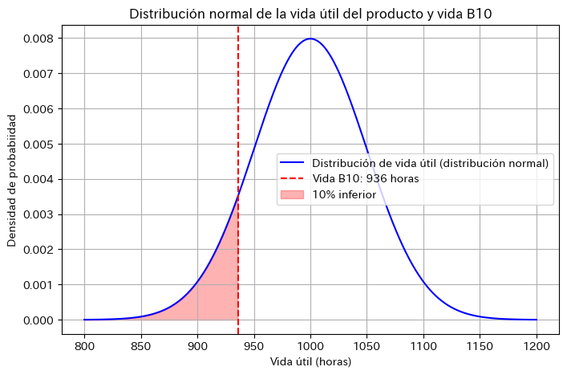

```python
import numpy as np
import scipy.stats as stats
import matplotlib.pyplot as plt

# Media poblacional y Desviación estándar poblacional
mu = 1000  # Media poblacional
sigma = 50  # Desviación estándar poblacional

# Cálculo de la vida B10 (percentil del 10% inferior)
b10_life = stats.norm.ppf(0.10, loc=mu, scale=sigma)
print(f"Vida B10: {b10_life:.0f} horas")

# Creación de un gráfico para la comprensión
x = np.linspace(mu - 4*sigma, mu + 4*sigma, 1000)
y = stats.norm.pdf(x, loc=mu, scale=sigma)

plt.figure(figsize=(8, 5))
plt.plot(x, y, label='Distribución de vida útil (distribución normal)', color='blue')
plt.axvline(b10_life, color='red', linestyle='dashed', label=f'Vida B10: {b10_life:.0f} horas')
plt.fill_between(x, y, where=(x <= b10_life), color='red', alpha=0.3, label='10% inferior')
plt.xlabel('Vida útil (horas)')
plt.ylabel('Densidad de probabiidad')
plt.title('Distribución normal de la vida útil del producto y vida B10')
plt.legend()
plt.grid()
plt.show()
```

3. ある工場のラインは、24時間の連続運転を実施し、故障が発生した場合は修理を行う。最近の平均故障率は０．１（回/日）で、一回の故障の修理に要する時間の平均は２．０（時間）である。このラインのMTBF、平均アベラビリティを求めよ。
4. Una línea de producción en una fábrica opera de manera continua durante 24 horas. Cuando ocurre una falla, se realiza una reparación. La tasa de fallas promedio reciente es de 0.1 (fallas/día), y el tiémpo promedio requerido para reparar una falla es de 2.0 horas. Calucule el MTBF (Tiempo Medio Entre Fallas) y la Disponibilidad Promedio de esta línea.

```python
# Tasa de fallas (fallas/día)
failure_rate = 0.1  # λ（lambda）

# Tiempo medio de reparación (horas)
mttr = 2.0  # Mean Time To Repair

# Cálculo del MTBF
mtbf = 1 / failure_rate  # Mean Time Between Failures

# MTBF (Tiempo Medio Entre Fallas)
availability = mtbf / (mtbf + mttr)

#
print(f"MTBF: {mtbf:.2f} horas")
print(f"Disponibilidad promedio: {availability:.3f}")
```

```
MTBF: 10.00 horas
Disponibilidad promedio: 0.833
```

4. ３の工場では、平均アベラビリティの向上に取り組んでいる。下記の対策の中で平均アベラビリティの向上に最も効果があるのはどれか。
- 一回の故障の修理に要する時間の平均はそのままで、平均故障率を０．０８（回/日）にする。
- 平均故障率はそのままで、一回の修理にようする時間の平均を１．０（時間）する。
- 平均故障率を０．０９（回/日）にし、一回の修理に要する時間の平均を１．５時間にする。
4. En la fáblica 3, están trabajando en la mejora de la disponibilidad promedio. ¿Quál de las siguientes medidas es la más efectiva para mejorar la disponibilidad promedio?
- Mantener el tiempo medio de reparación por falla y reducir la tasa de fallas promedio a 0.08 fallas/día.
- Mantener la tasa de fallas promedio y reducir el tiempo de reparación por falla a 1.0 horas.
- Reducir la tasa de fallas promedio a 0.09 fallas/día y reducir el tiempo promedio de reparación por falla a 1.5 horas.

```python
# Datos de cada medida
measures = {
    "Medida 1": {"failure_rate": 0.08, "mttr": 2.0},  # Reducir la tasa de fallas a 0.08
    "Medida 2": {"failure_rate": 0.1, "mttr": 1.0},   # Reducir el tiempo de reparación a 1. hora
    "Medida 3": {"failure_rate": 0.09, "mttr": 1.5},  # Reducir la tasa de fallas a 0.09 y
                                                      # el tiempo de reparación a 1.5
}

# Cálculo de la disponibilidad
availability_results = {}

for key, values in measures.items():
    failure_rate = values["failure_rate"]
    mttr = values["mttr"]

    mtbf = 1 / failure_rate  # Cálculo del MTBF
    availability = mtbf / (mtbf + mttr)  # Cálculo de la disponibilidad promedio

    availability_results[key] = availability

    # Salida de los resultados
    print(f"{key}: MTBF = {mtbf:.2f} horas, Disponibilidad promedio = {availability:.4f}")

# Selección de la mejor medida
best_measure = max(availability_results, key=availability_results.get)
print(f"\nLa medida más efectiva: {best_measure}")
```

```
Medida 1: MTBF = 12.50 horas, Disponibilidad promedio = 0.8621
Medida 2: MTBF = 10.00 horas, Disponibilidad promedio = 0.9091
Medida 3: MTBF = 11.11 horas, Disponibilidad promedio = 0.8811

La medida más efectiva: Medida 2
```

5. １０台の製品の寿命試験を行ったところ、下記の日数で故障した。１００日における信頼度を求めよ。
6. Se realizó una prueba de vida en 10 productos, y fallaron en los siguienes días, ¿Cuál es la confiabilidad a loa 100 días?
- [52, 65, 85, 95, 101, 115, 120, 150, 165, 170] días

```python
# Datos de días de fallo
failure_days = [52, 65, 85, 95, 101, 115, 120, 150, 165, 170]

# Ordenar los datos en orden ascendente
failure_days_sorted = np.sort(failure_days)

# Calcular la confiabilidad para coada día de fallo
n = len(failure_days_sorted)  # Número de productos que fallaron
times = failure_days_sorted  # Días de fallo
failures = np.ones(n)  # Todos los eventos de fallo se cuantan como 1

# Usar el método de estimación de Kaplan-Meier
df = pd.DataFrame({'time': times, 'failure': failures})

# Calcular la función de superviviencia en cada punto en el tiempo
df['risk_set'] = np.arange(n, 0, -1)  # Conjunto de riesgo en cada punto el tiempo
df['survival_prob'] = 1 - df['failure'] / df['risk_set']  # Probabilidad de superviviencia
df['survival_function'] = df['survival_prob'].cumprod()  # Producto de las funciones de supervivencia

# Calcular la confiabilidad en el día 100
time_100 = 100
survival_at_100 = df[df['time'] >= time_100]['survival_function'].iloc[0]

# 結果を表示
print(f"Mostrar el resultado dela confiabilidad en el día 100: {survival_at_100*100:.0f}%")
```

```
Mostrar el resultado dela confiabilidad en el día 100: 50%
```

## 16.3

1. ８個のアイテムを２４０時間測定したところ、このうち４個が以下の時間で故障した。この時のMTBFの推定値、信頼区間を求めよ。ただし寿命分布は指数分布に従うものとする。
2. Se midieron 8 elementos durante 240 horas, de los cuales 4 fallaron en los siguientes tiempos. Se debe calcular la estimación de la MTBF y el intervalo de confianza, asumiendo que la distribución de la vida sigue una distribución exponencial.
- [150, 160, 200, 220] horas

```python
import scipy.stats as stats

# Tiempo de fallo
fallos = [150, 160, 200, 220]

# Tiempo total de prueba de los productos censurados（4 artículos × 240 horas）
tiempo_corte = 240 * 4

# Tiempo total de prueba T
# = Suma de los tiemos de fallo + Tiempo de prueba de los productos censurados
tiempo_total = sum(fallos) + tiempo_corte

# Número de fallos (r=
r = len(fallos)

# Estimación puntual de MTBF
mtbf = tiempo_total / r

# Cálculo del intervalo de confianza
# Nivel de significaansía alpha = 0.05
alpha = 0.05

# Grados de libertad
df = 2 * r

# Punto percentil de la distribución chi-cuadrada
chi2_lower = stats.chi2.ppf(1 - alpha / 2, df)
chi2_upper = stats.chi2.ppf(alpha / 2, df)

# Cálculo del intervalo de confianza
lower_bound = 2 * tiempo_total / chi2_lower
upper_bound = 2 * tiempo_total / chi2_upper

# Mostrar resultados
print(f"MTBF estimado: {mtbf:.1f} horas")
print(f"Intervalo de confianza: ({lower_bound:.1f}, {upper_bound:.1f}) horas")
```

```
MTBF estimado: 422.5 horas
Intervalo de confianza: (192.8, 1550.7) horas
```

2. 8個のアイテムを４個故障するまで測定したところ、故障時間が以下のように観測された。この時のMTBFの点推定、信頼区間を求めよ。ただし、寿命分布は指数分布にしたがうものとする。
3. Se realizaron pruebas de vida en 8 artículos hasta que fallaron 4 de ellos. Los tiempo de fallo observados son los siguientes. Calucule la estimación puntual del MTBF y el intervalo de confianza. Suponiendo que la distribución de vida sigue una distribución exponencial.
- [150, 160, 200, 220] horas

```python
# Tiempo de fallo
fallos = [150, 160, 200, 220]

# Tiempo de prueba de los productos censurados（4 artículos × 220 horas）
tiempo_corte = 220 * 4

# Tiempo total de prueba T
# = Suma de los tiempos de fallo + Tiempo de prueba de los productos centurados
tiempo_total = sum(fallos) + tiempo_corte

# Número de fallos (r=
r = len(fallos)

# Estimación puntual de MTBF
mtbf = tiempo_total / r

# Cálculo del intevalo de confianza
# Nivel de significancia alpha = 0.05
alpha = 0.05

# Grados de libertad
df = 2 * r

# Punto percentil de la distribución chi-cuadrada
chi2_lower = stats.chi2.ppf(1 - alpha / 2, df)
chi2_upper = stats.chi2.ppf(alpha / 2, df)

# Cálculo del intervalo de confianza
lower_bound = 2 * tiempo_total / chi2_lower
upper_bound = 2 * tiempo_total / chi2_upper

# Mostrar resultados
print(f"MTBF estimado: {mtbf:.1f} horas")
print(f"Intervalo de confianza: ({lower_bound:.1f}, {upper_bound:.1f}) horas")
```

```
MTBF estimado: 402.5 horas
Intervalo de confianza: (183.6, 1477.2) horas
```